# Final_Project

Benjamin Salzberg

May 19, 2019

```r
library(tidyverse)
library(stringr)
library(knitr)
library(pracma)
All_Education_Data <- read_csv("states_all.csv")
```

These are the libraries and datasets that we will be making use of. Tidyverse is a very useful library, it makes if far easier to manipulate data. stringr allows us to easily interact with strings, which most data is. knitr also allows for easier data manipulation. Finally, pracma provides the strcmp() function, which allows for easy comparison for strings as == is incorrect when dealing with them.

```r
All_Education_Data
```

```
## # A tibble: 1,492 x 25
##    PRIMARY_KEY STATE  YEAR ENROLL TOTAL_REVENUE FEDERAL_REVENUE
##    <chr>       <chr> <dbl>  <dbl>         <dbl>           <dbl>
##  1 1992_ALABA… ALAB…  1992     NA       2678885          304177
##  2 1992_ALASKA ALAS…  1992     NA       1049591          106780
##  3 1992_ARIZO… ARIZ…  1992     NA       3258079          297888
##  4 1992_ARKAN… ARKA…  1992     NA       1711959          178571
##  5 1992_CALIF… CALI…  1992     NA      26260025         2072470
##  6 1992_COLOR… COLO…  1992     NA       3185173          163253
##  7 1992_CONNE… CONN…  1992     NA       3834302          143542
##  8 1992_DELAW… DELA…  1992     NA        645233           45945
##  9 1992_DISTR… DIST…  1992     NA        709480           64749
## 10 1992_FLORI… FLOR…  1992     NA      11506299          788420
## # … with 1,482 more rows, and 19 more variables: STATE_REVENUE <dbl>,
## #   LOCAL_REVENUE <dbl>, TOTAL_EXPENDITURE <dbl>,
## #   INSTRUCTION_EXPENDITURE <dbl>, SUPPORT_SERVICES_EXPENDITURE <dbl>,
## #   OTHER_EXPENDITURE <dbl>, CAPITAL_OUTLAY_EXPENDITURE <dbl>,
## #   GRADES_PK_G <dbl>, GRADES_KG_G <dbl>, GRADES_4_G <dbl>,
## #   GRADES_8_G <dbl>, GRADES_12_G <dbl>, GRADES_1_8_G <dbl>,
## #   GRADES_9_12_G <dbl>, GRADES_ALL_G <dbl>, AVG_MATH_4_SCORE <dbl>,
## #   AVG_MATH_8_SCORE <dbl>, AVG_READING_4_SCORE <dbl>,
## #   AVG_READING_8_SCORE <dbl>
```

This is our dataset, 1492 entries for states over different years, it records the number of students enrolled, the revenue and expenditure, and the number of people in each grade. However, there is some missing data for several of these datasets, this will effect how we can use the data.

This is how the data is divided, each column is described here for reference.  
PRIMARY_KEY = the primary key, a combination of YEAR and STATE  
STATE = the state being represented  
YEAR = the year the data is from

ENROLL = the number who enrolled in school

TOTAL_REVENUE = amount of money made for state, federal+state+local  
FEDERAL_REVENUE = federal revenue  
STATE_REVENUE = state revenue  
LOCAL_REVENUE = local revenue

TOTAL_EXPENDITURE = Total state spent  
INSTRUCTION_EXPENDITURE = amount spent on instruction  
SUPPORT_SERVICES_EXPENDITURE = amount spent on support services  
OTHER_EXPENDITURE = amount spent on other things  
CAPITAL_OUTLAY_EXPENDITURE = money spent to repair or replace assets

GRADES_PK_G = Number of students in Pre-Kindergarten education  
GRADES_KG_G = Number of students in Kindergarten through twelfth grade.  
GRADES_4_G = Number of students in fourth grade.  
GRADES_8_G = Number of students in eighth grade.  
GRADES_12_G = Number of students in twelfth grade.  
GRADES_1_8_G = Number of students in the first through eighth grades.  
GRADES_9_12_G = Number of students in the ninth through twelfth grades.  
GRADES_ALL_G = The count of all students in the state. Comparable to ENROLL in the financial data (which is the U.S. Census Bureau’s estimate for students in the state).

AVG_MATH_4_SCORE = The state’s average score for fourth graders taking the NAEP math exam.  
AVG_MATH_8_SCORE = The state’s average score for eight graders taking the NAEP math exam.  
AVG_READING_4_SCORE = The state’s average score for fourth graders taking the NAEP reading exam.  
AVG_READING_8_SCORE = The state’s average score for eighth graders taking the NAEP reading exam.

We first need to define the timespan that we should be looking at which is **1995-2015**. We also need to ensure that we are looking at the same data for every year, in this case, only the data from individual states instead of various other groups who reported data in this dataset.

```r
# We start by setting the limits of the years. We then remove everything that is not one of the 50 states.
Education_Data <- All_Education_Data %>%
  filter(YEAR >= 1995 & YEAR <= 2015) %>%
  filter(STATE != "AMERICAN_SAMOA" & STATE != "AS" & STATE != "BI" & STATE != "BIE" & STATE!="BUREAU_OF_INDIAN_AFFAIRS"&STATE!="BUREAU_OF_INDIAN_EDUCATIO"&STATE!="BUREAU_OF_INDIAN_EDUCATION"&STATE!="COMMONWEALTH_OF_MARIANAS"&STATE!="DD"&STATE!="DOD"&STATE!="DOD_-_DOMESTIC"&STATE!="DOD_-_FOREIGN"&STATE!="DOD_-_OVERSEAS"&STATE!="DOD_(OVERSEAS_AND_DOMESTIC_COMBINED)"&STATE!="DOD_DOMESTIC"&STATE!="DOD_OVERSEAS"&STATE!="GU"&STATE!="GUAM"&STATE!="MP"&STATE!="PR"&STATE!="VI"&STATE!="VIRGIN_ISLANDS"&STATE!="NORTHERN_MARIANAS"&STATE!="PUERTO_RICO"&STATE!="DISTRICT_OF_COLUMBIA"&STATE!="DEPARTMENT_OF_DEFENSE"&STATE!="DEPARTMENT_OF_DEFENSE_EDUCATION_ACTIVITY"&STATE!="NORTHERN_MARIANA_ISLANDS"&STATE!="U.S._VIRGIN_ISLANDS")
Education_Data
```

```
## # A tibble: 1,052 x 25
##    PRIMARY_KEY STATE  YEAR ENROLL TOTAL_REVENUE FEDERAL_REVENUE
##    <chr>       <chr> <dbl>  <dbl>         <dbl>           <dbl>
##  1 1995_ALABA… ALAB…  1995 7.27e5       3367437          328957
##  2 1995_ALASKA ALAS…  1995 1.25e5       1117068          123037
##  3 1995_ARIZO… ARIZ…  1995 7.35e5       3815218          376437
##  4 1995_ARKAN… ARKA…  1995 4.48e5       2057550          197556
##  5 1995_CALIF… CALI…  1995 5.30e6      29512214         2612241
##  6 1995_COLOR… COLO…  1995 6.40e5       3709875          201341
##  7 1995_CONNE… CONN…  1995 4.90e5       4420632          147466
##  8 1995_DELAW… DELA…  1995 1.07e5        802018           51682
##  9 1995_FLORI… FLOR…  1995 2.11e6      13242710          938814
## 10 1995_GEORG… GEOR…  1995 1.27e6       7052825          458452
## # … with 1,042 more rows, and 19 more variables: STATE_REVENUE <dbl>,
## #   LOCAL_REVENUE <dbl>, TOTAL_EXPENDITURE <dbl>,
## #   INSTRUCTION_EXPENDITURE <dbl>, SUPPORT_SERVICES_EXPENDITURE <dbl>,
## #   OTHER_EXPENDITURE <dbl>, CAPITAL_OUTLAY_EXPENDITURE <dbl>,
## #   GRADES_PK_G <dbl>, GRADES_KG_G <dbl>, GRADES_4_G <dbl>,
## #   GRADES_8_G <dbl>, GRADES_12_G <dbl>, GRADES_1_8_G <dbl>,
## #   GRADES_9_12_G <dbl>, GRADES_ALL_G <dbl>, AVG_MATH_4_SCORE <dbl>,
## #   AVG_MATH_8_SCORE <dbl>, AVG_READING_4_SCORE <dbl>,
## #   AVG_READING_8_SCORE <dbl>
```

We have a problem here, There are 1052 rows, which is 2 extra than what should be in there. This means we need to find where the error is. This can be done by looking at every state and seeing where the extra data is. We will do this by using a function defined below.

```r
# first get the values that can be the same, this gives us a list.
keys <- Education_Data$PRIMARY_KEY
# then make a function that finds which values are the same
find_doubles <- function(lst)
{
  c = ""
  lst
  integer = 0
  for (a in lst) {
    integer = 0
    for (b in lst) {
      if (strcmp(a, b)){
        integer = integer + 1
      }
    }
    if (integer > 1)
    {
      c = a
    }
  }
  c
}
#running the function gives us the answer.
keys %>% find_doubles()
```

```
## [1] "2008_VIRGINIA"
```

The above function called find doubles is an R function. This function takes a single list or column. It then makes use of a pair of for each loops. it then counts the number of occurences of each element in the list. The comparison occurs in strcmp, which is abstracted out comparison of strings. for each occurnece it increases the variable integer by 1. and if it is larger than 1 it returns that value.  
And we now have our answer, the duplicates are in 2008_VIRGINIA, now we must remove them.

```r
Virginia_Extra <- Education_Data %>%
  filter(YEAR==2008&STATE =="VIRGINIA")

newGRADE_PK_G = sum(Virginia_Extra$GRADES_PK_G)
newGRADES_KG_G = sum(Virginia_Extra$GRADES_KG_G)
newGRADES_4_G = sum(Virginia_Extra$GRADES_4_G)
newGRADES_8_G = sum(Virginia_Extra$GRADES_8_G)
newGRADES_12_G = sum(Virginia_Extra$GRADES_12_G)
newGRADES_1_8_G = sum(Virginia_Extra$GRADES_1_8_G)
newGRADES_9_12_G = sum(Virginia_Extra$GRADES_9_12_G)
newGRADES_ALL_G = sum(Virginia_Extra$GRADES_ALL_G)
newRow = data.frame(PRIMARY_KEY = "2008_VIRGINIA", STATE = "VIRGINIA", YEAR = 2008, ENROLL = 1230857, TOTAL_REVENUE = 14768120, FEDERAL_REVENUE = 897627, STATE_REVENUE = 5957786, LOCAL_REVENUE = 7912707, TOTAL_EXPENDITURE = 15236306, INSTRUCTION_EXPENDITURE = 8003167, SUPPORT_SERVICES_EXPENDITURE = 4645375, OTHER_EXPENDITURE = 555074, CAPITAL_OUTLAY_EXPENDITURE = 1528769, GRADES_PK_G = newGRADE_PK_G, GRADES_KG_G = newGRADES_KG_G, GRADES_4_G = newGRADES_4_G, GRADES_8_G = newGRADES_8_G, GRADES_12_G = newGRADES_12_G, GRADES_1_8_G = newGRADES_1_8_G, GRADES_9_12_G = newGRADES_9_12_G, GRADES_ALL_G = newGRADES_ALL_G, AVG_MATH_4_SCORE = NA, AVG_MATH_8_SCORE = NA, AVG_READING_4_SCORE = NA, AVG_READING_8_SCORE = NA)

Education_Data<-Education_Data %>%
  filter(PRIMARY_KEY!="2008_VIRGINIA") %>%
  rbind(newRow)
Education_Data
```

```
## # A tibble: 1,050 x 25
##    PRIMARY_KEY STATE  YEAR ENROLL TOTAL_REVENUE FEDERAL_REVENUE
##    <chr>       <chr> <dbl>  <dbl>         <dbl>           <dbl>
##  1 1995_ALABA… ALAB…  1995 7.27e5       3367437          328957
##  2 1995_ALASKA ALAS…  1995 1.25e5       1117068          123037
##  3 1995_ARIZO… ARIZ…  1995 7.35e5       3815218          376437
##  4 1995_ARKAN… ARKA…  1995 4.48e5       2057550          197556
##  5 1995_CALIF… CALI…  1995 5.30e6      29512214         2612241
##  6 1995_COLOR… COLO…  1995 6.40e5       3709875          201341
##  7 1995_CONNE… CONN…  1995 4.90e5       4420632          147466
##  8 1995_DELAW… DELA…  1995 1.07e5        802018           51682
##  9 1995_FLORI… FLOR…  1995 2.11e6      13242710          938814
## 10 1995_GEORG… GEOR…  1995 1.27e6       7052825          458452
## # … with 1,040 more rows, and 19 more variables: STATE_REVENUE <dbl>,
## #   LOCAL_REVENUE <dbl>, TOTAL_EXPENDITURE <dbl>,
## #   INSTRUCTION_EXPENDITURE <dbl>, SUPPORT_SERVICES_EXPENDITURE <dbl>,
## #   OTHER_EXPENDITURE <dbl>, CAPITAL_OUTLAY_EXPENDITURE <dbl>,
## #   GRADES_PK_G <dbl>, GRADES_KG_G <dbl>, GRADES_4_G <dbl>,
## #   GRADES_8_G <dbl>, GRADES_12_G <dbl>, GRADES_1_8_G <dbl>,
## #   GRADES_9_12_G <dbl>, GRADES_ALL_G <dbl>, AVG_MATH_4_SCORE <dbl>,
## #   AVG_MATH_8_SCORE <dbl>, AVG_READING_4_SCORE <dbl>,
## #   AVG_READING_8_SCORE <dbl>
```

We do this by first taking the values that are the same in each. we then add the values that are different for each column using the sum function. The NA values are there because that year is entirely NA.  
Now that they are gone, we can look at the data. We will first look at the total expenditure vs year, the enrollment per year, and enrollment vs total expenditure.

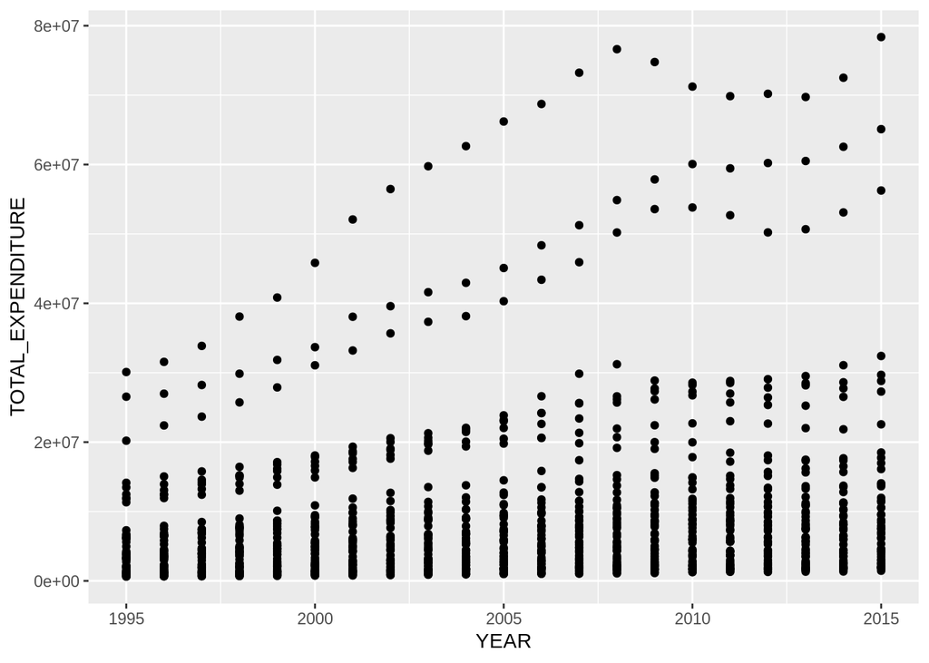

```r
plot1 <- Education_Data %>%
  ggplot(mapping=aes(y=TOTAL_EXPENDITURE, x=YEAR)) +
    geom_point()
plot1
```

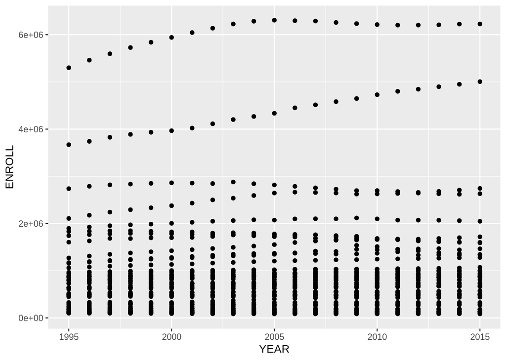

```r
plot2 <- Education_Data %>%
  ggplot(mapping=aes(y=ENROLL, x=YEAR)) +
    geom_point()
plot2
```

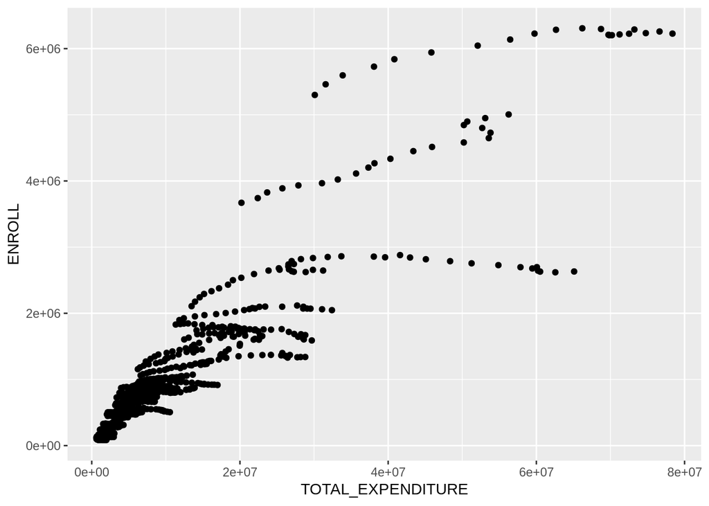

```r
plot2 <- Education_Data %>%
  ggplot(mapping=aes(y=ENROLL, x=TOTAL_EXPENDITURE)) +
    geom_point()
plot2
```

All we see is a great deal of data, we can’t even really see general trends, it tells us very little. as such we should look at labeling everything.

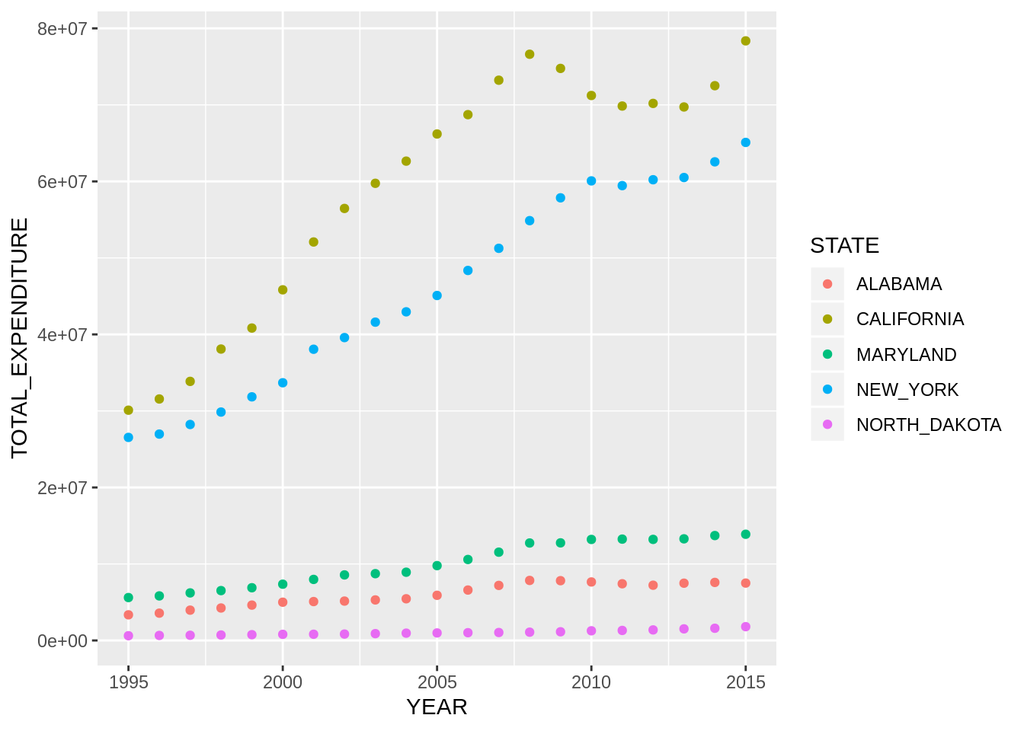

```r
Expend_plot <- Education_Data %>%
  filter(STATE == "MARYLAND" | STATE == "CALIFORNIA" | STATE == "NEW_YORK" | STATE == "ALABAMA" | STATE == "NORTH_DAKOTA") %>%
  group_by(STATE, YEAR) %>%
  ggplot(mapping=aes(y=TOTAL_EXPENDITURE, x=YEAR, color = STATE)) +
    geom_point()
Expend_plot
```

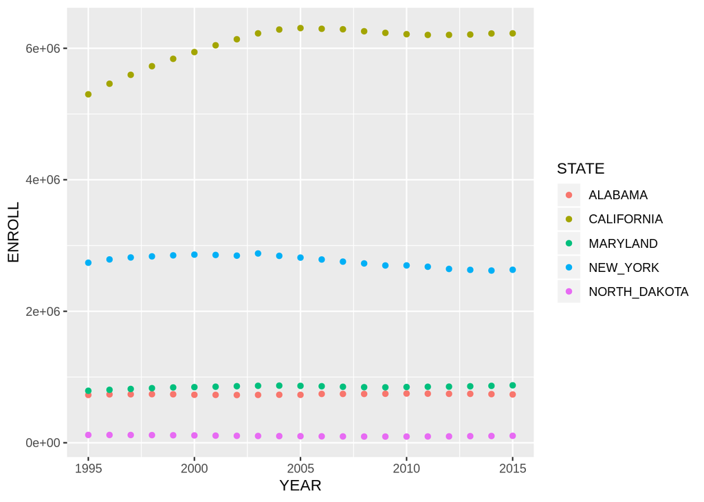

```r
Expend_plot <- Education_Data %>%
  filter(STATE == "MARYLAND" | STATE == "CALIFORNIA" | STATE == "NEW_YORK" | STATE == "ALABAMA" | STATE == "NORTH_DAKOTA") %>%
  group_by(STATE, YEAR) %>%
  ggplot(mapping=aes(y=ENROLL, x=YEAR, color = STATE)) +
    geom_point()
Expend_plot
```

This shows us each one differently. and lets us compare visually these graphs. Note that we only use 5 states because all of them would have overwhelmed the graph hiding a great deal data.  
We can also look at expenditure and revenue for each year.

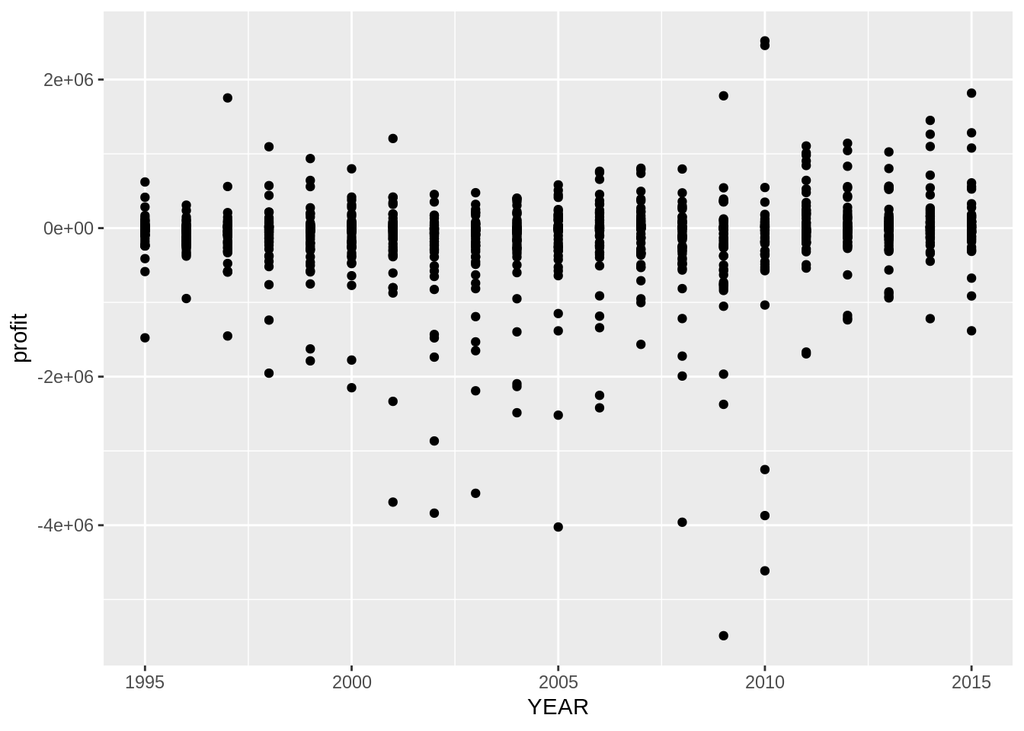

```r
plot3 <- Education_Data %>%
  group_by(STATE, YEAR) %>%
  summarise(profit = TOTAL_REVENUE - TOTAL_EXPENDITURE)
plot3 %>%
  ggplot(mapping=aes(y=profit, x=YEAR)) +
    geom_point()
```

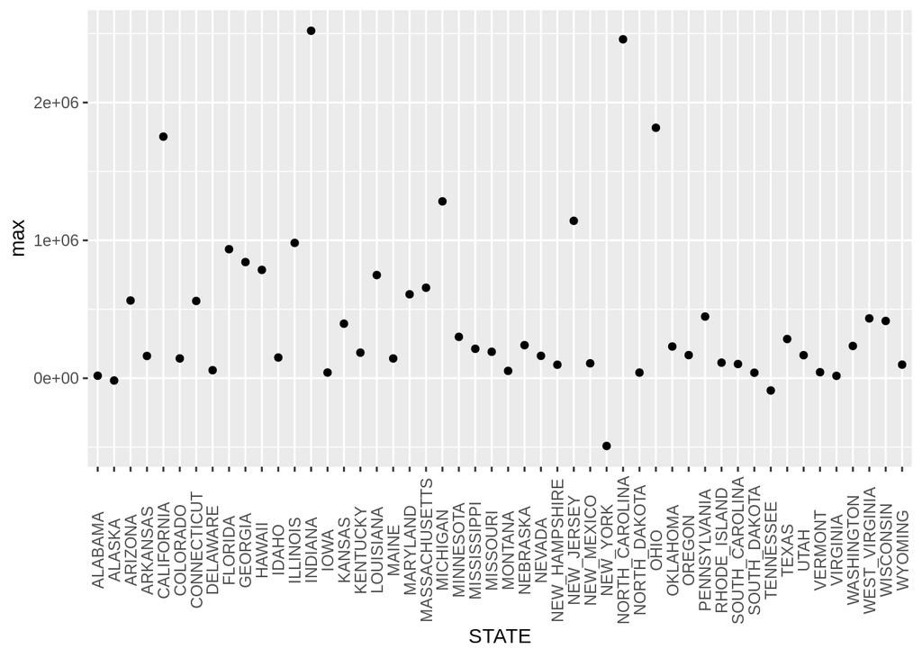

```r
calc_largest <- Education_Data %>%
  group_by(STATE, YEAR) %>%
  summarise(profit = TOTAL_REVENUE - TOTAL_EXPENDITURE) %>%
  group_by(STATE) %>%
  summarise(max = max(profit))
calc_largest %>%
  ggplot(mapping=aes(y=max, x=STATE)) +
  geom_point() +
  theme(axis.text.x = element_text(angle = 90, vjust = 0.5))
```

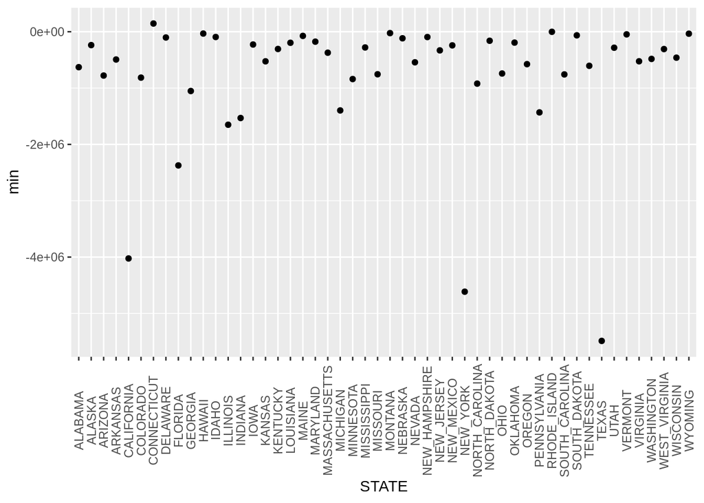

```r
calc_smallest <- Education_Data %>%
  group_by(STATE, YEAR) %>%
  summarise(profit = TOTAL_REVENUE - TOTAL_EXPENDITURE) %>%
  group_by(STATE) %>%
  summarise(min = min(profit))
calc_smallest %>%
  ggplot(mapping=aes(y=min, x=STATE)) +
  geom_point() +
  theme(axis.text.x = element_text(angle = 90, vjust = 0.5))
```

```r
calc_largest %>%
  summarize(MAXIMUM=max(max))
```

```
## # A tibble: 1 x 1
##   MAXIMUM
##     <dbl>
## 1 2520706
```

```r
calc_smallest %>%
  summarize(MINIMUM=min(min))
```

```
## # A tibble: 1 x 1
##    MINIMUM
##      <dbl>
## 1 -5487742
```

This gives us the maximum and minimum values as data frames.  
lets take a look at number of students enrolled vs how much money was spent on education each year. ENROLL VS TOTAL_EXPENDITURE  
We want to use violin plots to take a look at the total expenditures for each year. we use this instead of scatter plots to allow us to see how the scatterplot would have been arrayed and show relatively how many are at each point rather than just seeing a mass as is shown above. we use the mutate and cut functions to divide into each year. we then group by the state and the newly generated cols value that tells us where , we then summarise to find the values. we use the theme to turn thevalues on the side, to make them readable.

```r
plotyear1 <- Education_Data %>%
  filter(YEAR >= 2010) %>%
  mutate(cols = cut(YEAR, breaks = 5)) %>%
  group_by(STATE, cols) %>%
  summarise(ENROLL = mean(ENROLL), TOTAL_EXPENDITURE=mean(TOTAL_EXPENDITURE))%>%
  ggplot(mapping=aes(y=ENROLL, x=TOTAL_EXPENDITURE)) +
    geom_violin() +
    facet_grid(~cols)+
    theme(axis.text.x = element_text(angle = 90, vjust = 0.5))
plotyear2 <- Education_Data %>%
  filter(YEAR <= 2010 & YEAR >=2005) %>%
  mutate(cols = cut(YEAR, breaks = 5)) %>%
  group_by(STATE, cols) %>%
  summarise(ENROLL = mean(ENROLL), TOTAL_EXPENDITURE=mean(TOTAL_EXPENDITURE))%>%
  ggplot(mapping=aes(y=ENROLL, x=TOTAL_EXPENDITURE)) +
    geom_violin() +
    facet_grid(~cols)+
    theme(axis.text.x = element_text(angle = 90, vjust = 0.5))
plotyear3 <- Education_Data %>%
  filter(YEAR <=2004) %>%
  mutate(cols = cut(YEAR, breaks = 5)) %>%
  group_by(STATE, cols) %>%
  summarise(ENROLL = mean(ENROLL), TOTAL_EXPENDITURE=mean(TOTAL_EXPENDITURE))%>%
  ggplot(mapping=aes(y=ENROLL, x=TOTAL_EXPENDITURE)) +
    geom_violin() +
    facet_grid(~cols)+
    theme(axis.text.x = element_text(angle = 90, vjust = 0.5))
```

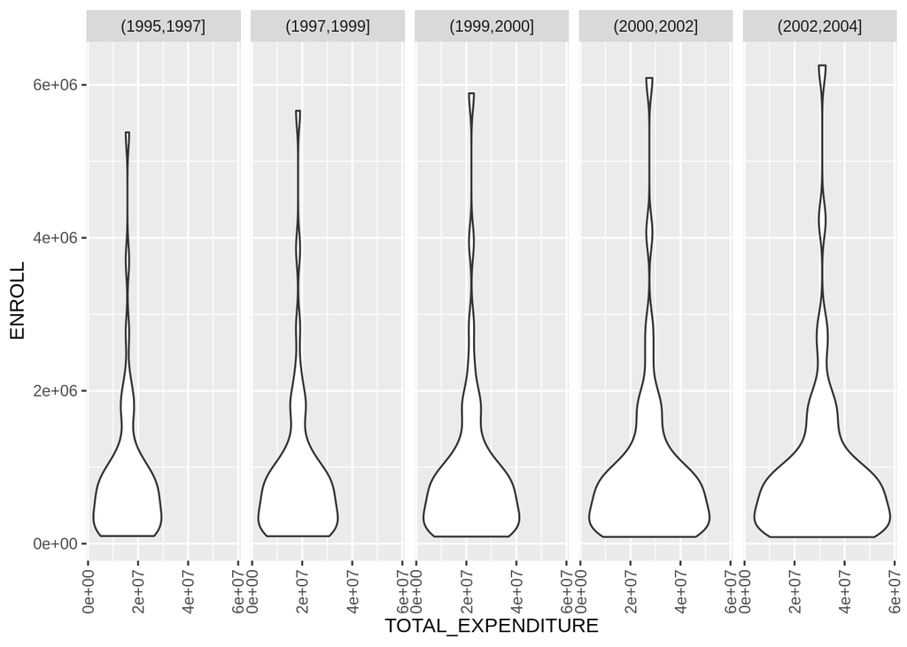

```r
plotyear3
```

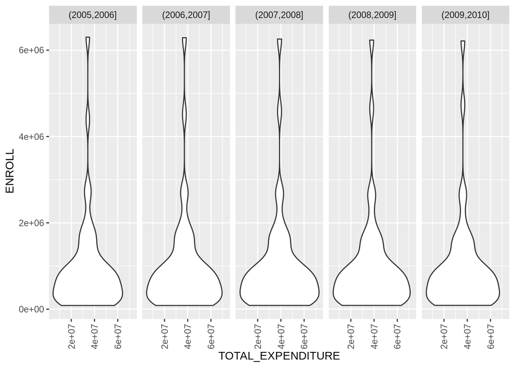

```r
plotyear2
```

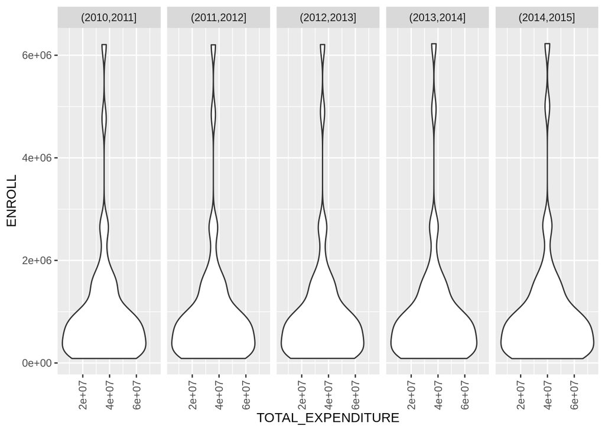

```r
plotyear1
```

These Violin plots give us a good idea of how the values are grouped. we can see some clear outliers for enrollment, but not as many as for total expenditure.

```r
profit_data <- plot3 %>%
  filter(STATE == "MARYLAND" | STATE == "CALIFORNIA" | STATE == "NEW_YORK" | STATE == "ALABAMA" | STATE == "NORTH_DAKOTA")
regression <- broom::tidy(lm(profit~YEAR+STATE, profit_data))
regression
```

```
## # A tibble: 6 x 5
##   term                estimate std.error statistic       p.value
##   <chr>                  <dbl>     <dbl>     <dbl>         <dbl>
## 1 (Intercept)        16597426. 28438422.     0.584 0.561
## 2 YEAR                  -8356.    14183.    -0.589 0.557
## 3 STATECALIFORNIA     -538515.   271592.    -1.98  0.0502
## 4 STATEMARYLAND        298451.   271592.     1.10  0.274
## 5 STATENEW_YORK      -1755987.   271592.    -6.47  0.00000000384
## 6 STATENORTH_DAKOTA    144232.   271592.     0.531 0.597
```

This is showing us the data, the intercept, it then tells us about the estimate for each state, the base is Alabama. and increases or decreases depending on state exist for each.

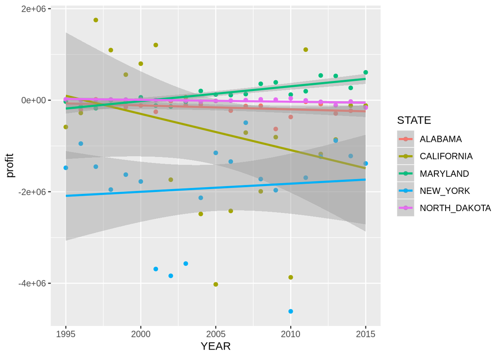

```r
profit_data %>%
  ggplot(mapping=aes(y=profit, x=YEAR, color = STATE)) +
    geom_point() +
    geom_smooth(method = lm)
```

this a a graph of the above data, for some states, there are enourmous error lines for several states because of the profit outliers for each year. there are others where the error bars are very small, this is because the linear regression is very accurate for each value. Below is the data not seperated by state, and further below that is for all the data in the dataset.

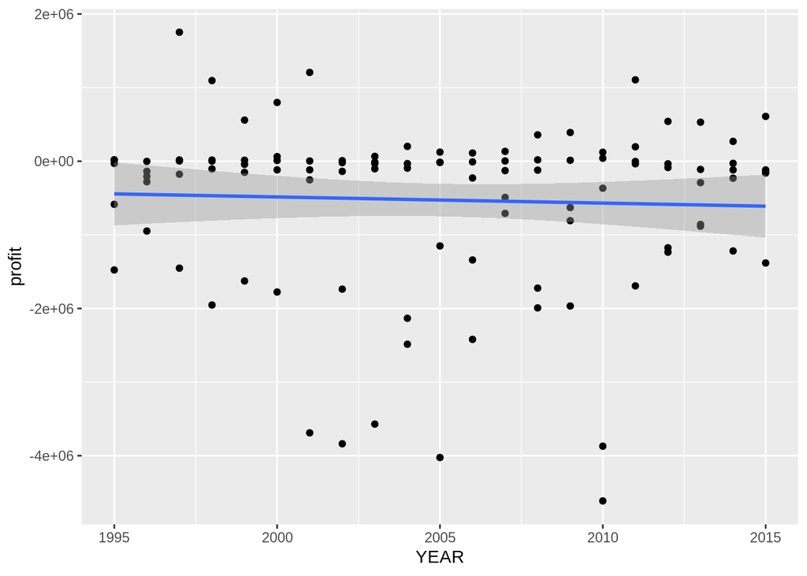

```r
profit_data %>%
  ggplot(mapping=aes(y=profit, x=YEAR)) +
    geom_point() +
    geom_smooth(method = lm)
```

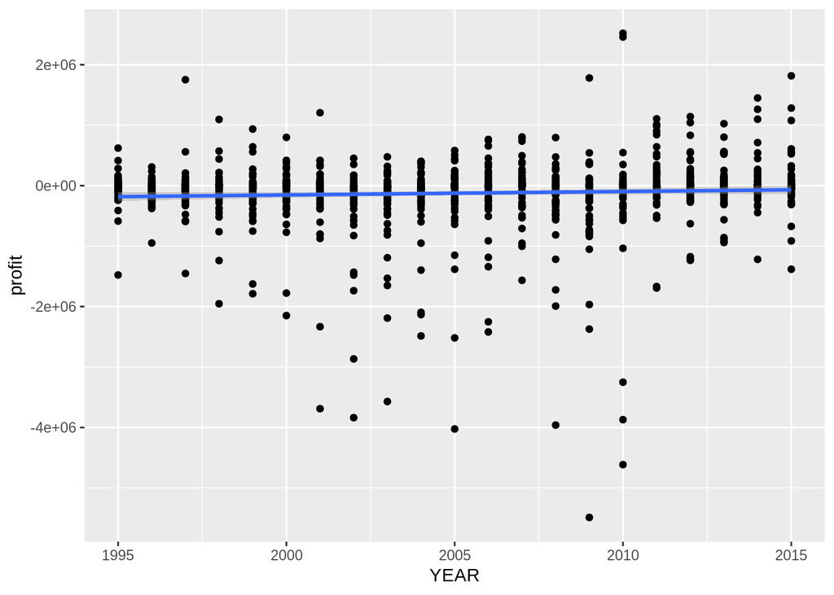

```r
plot3 %>%
  ggplot(mapping=aes(y=profit, x=YEAR)) +
    geom_point() +
    geom_smooth(method = lm)
```